# Final Project Presentation

12/6/2021

## Background

- Cycles of Public Action and Private Interest
- Movement towards Deinstitutionalization and Reprivatization
- Debate: Are for-profit healthcare facilities beneficial or detrimental to its patients?
  - Improved patient care and reduced prices
  - Quality decreases, accessibility and availability decreases

## Research Question

- Do the treatments offered at a mental health facility predict the type of ownership of the facility: private for-profit, private non-profit, and public?

## Methods: Finding the Data

- National Mental Health Services Survey (2019, most recent)
- Chose Ownership
- Selected Treatments: Psychotherapy, Emergency, Substance Abuse, PTSD, Eating Disorder, Alzheimer’s or Dementia, Electroconvulsive

## Methods: Tidying Data for Visualizations

- Recoded variables and observation cells
- Pivot for visualizations
  - Bar plots

## Methods: Classification Tree

- Classification Tree to predict ownership from treatments offered
- Training and Testing Data, Pruning, Confusion Matrix

## Selected Treatments and their Availability in Facilities Across the US

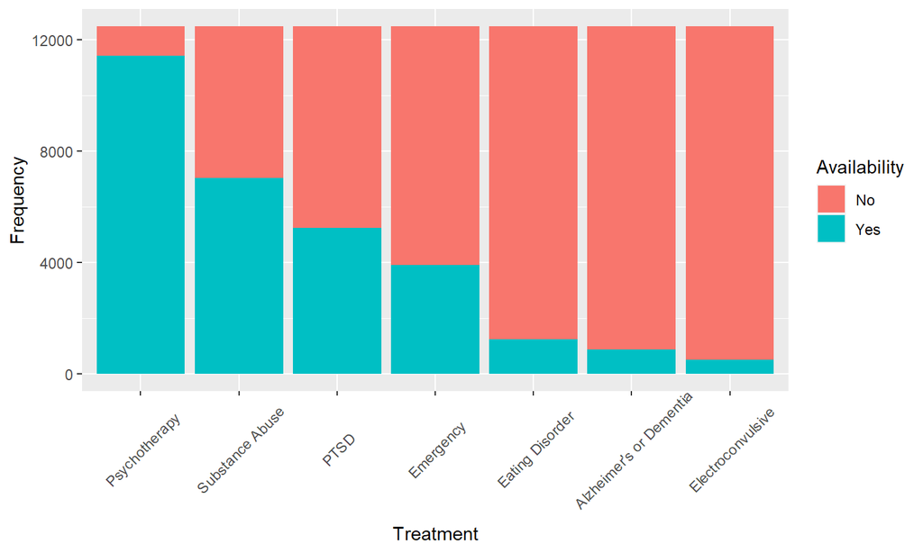

## Faceted by Ownership

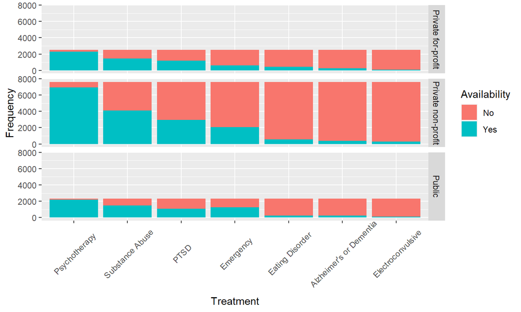

## Faceted by Ownership (%)

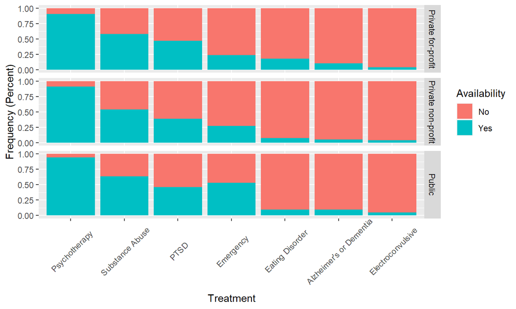

## Results: Treatment Visualization

- Visualizations
  - Psychotherapy, substance abuse, and emergency treatments provided more in public institutions
  - Eating disorder treatments provided more in for-profit institutions

## Payment Types and their Availability in Facilities Across the US

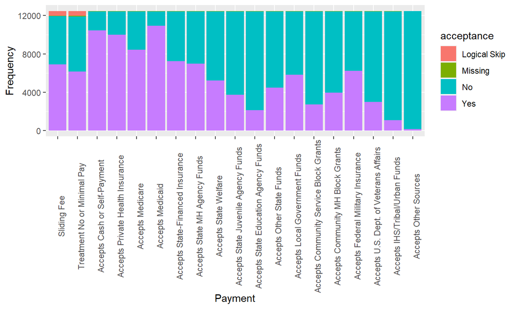

## Faceted by Ownership

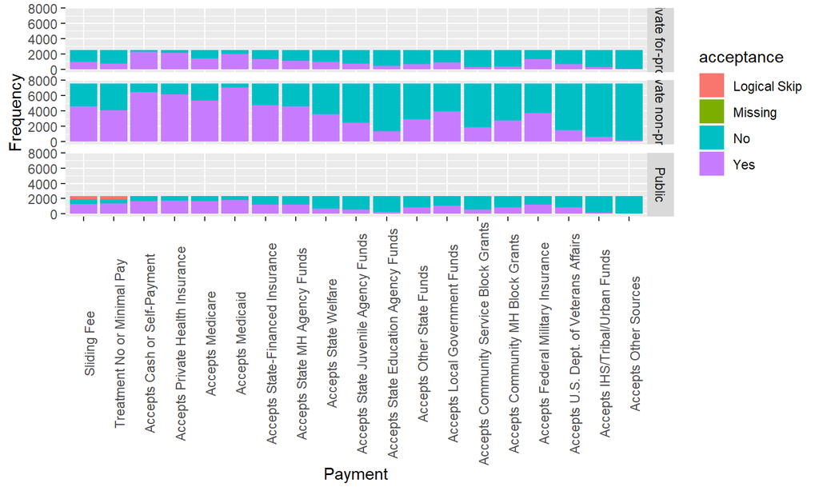

## Faceted by Ownership (%)

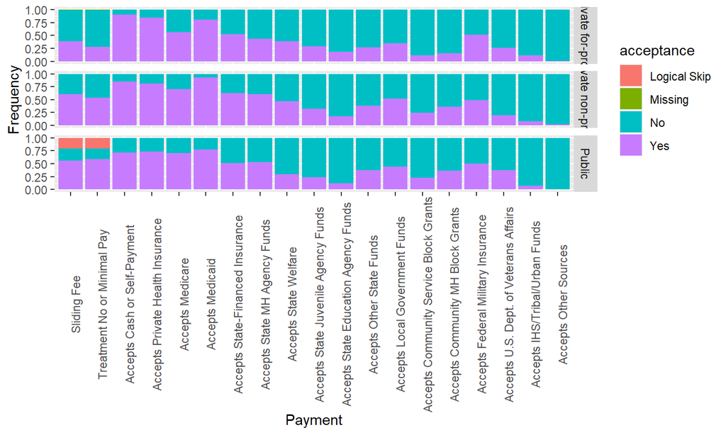

## Results: Funds Visualization

- Highest accepted payment types are ones you pay for:
  - Cash
  - Personal Health Insurance
  - Medicare/Medicaid (taxes)
- Other state provided funds are less accepted
  - Needs-based

## Classification Tree (Decision Tree)

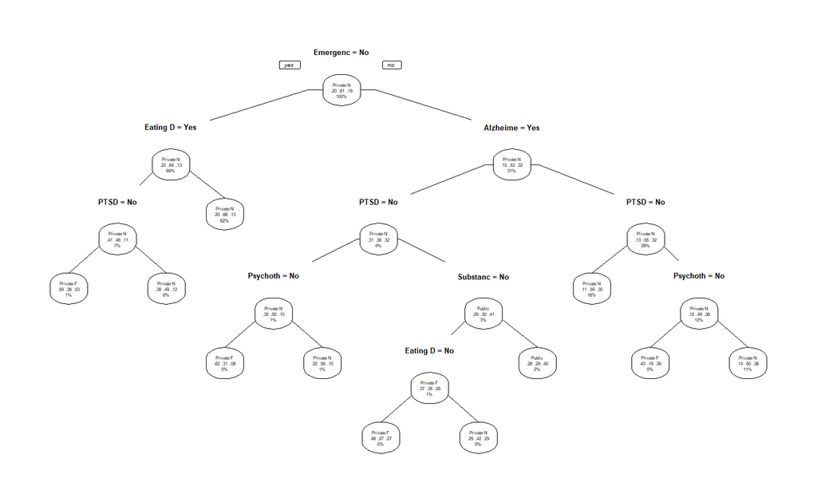

## Pruned Classification Tree

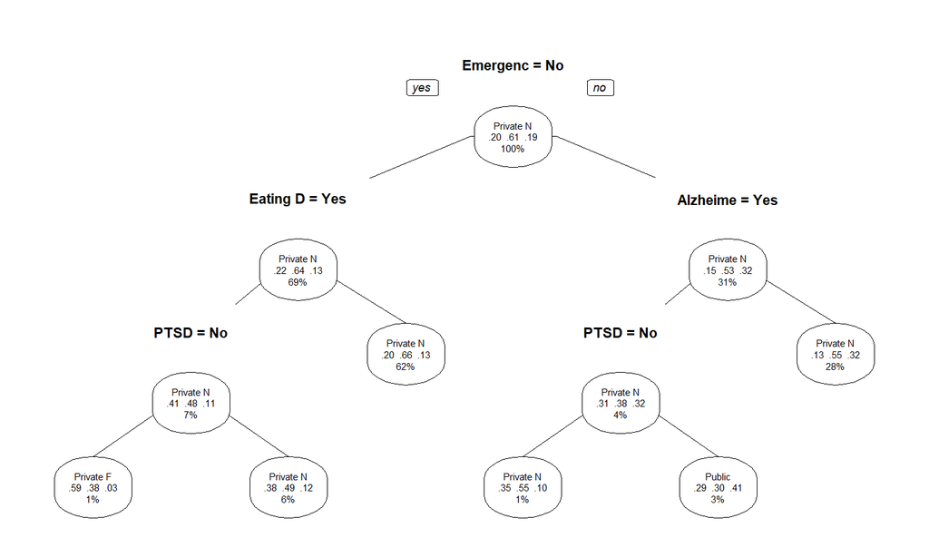

## Confusion Matrix pt. 1

```
## Confusion Matrix and Statistics
##
##                     Reference
## Prediction           Private For-Profit Private Non-Profit Public
##   Private For-Profit                 14                 10      5
##   Private Non-Profit                494               1540    400
##   Public                             10                  6     16
##
## Overall Statistics
##
##                Accuracy : 0.6293
##                  95% CI : (0.61, 0.6483)
##     No Information Rate : 0.6236
##     P-Value [Acc > NIR] : 0.2889
##
##                   Kappa : 0.0421
##
##  Mcnemar's Test P-Value : <2e-16
##
## Statistics by Class:
##
##                      Class: Private For-Profit Class: Private Non-Profit
## Sensitivity                           0.027027                   0.98972
## Specificity                           0.992413                   0.04792
## Pos Pred Value                        0.482759                   0.63270
## Neg Pred Value                        0.795620                   0.73770
## Prevalence                            0.207615                   0.62365
## Detection Rate                        0.005611                   0.61723
## Detection Prevalence                  0.011623                   0.97555
## Balanced Accuracy                     0.509720                   0.51882
##                      Class: Public
## Sensitivity               0.038005
## Specificity               0.992285
## Pos Pred Value            0.500000
## Neg Pred Value            0.835566
## Prevalence                0.168737
## Detection Rate            0.006413
## Detection Prevalence      0.012826
## Balanced Accuracy         0.515145
```

## Confusion Matrix pt. 2

- Statistics by Class:
- Sensitivity
  - Private For-Profit: 0.027027
  - Private Non-Profit: 0.98972
  - Public: 0.038005
- Specificity
  - Private For-Profit: 0.992413
  - Private Non-Profit: 0.04792
  - Public: 0.992285

## Map of Treatments across the US

[interactive chart not shown]